# Analysis with Raster Data Using R and rasterList Package: saving functions ot any kind of data in a grid cell

Emanuele Cordano

2023-03-03

## Abstract

The **rasterList** package has been developed to create a S4 class object that can manage complex operations and objects in a spatially gridded map, i.e. a raster map. The *rasterList-Class* (Cordano and Others (2018)) object differs from a traditional raster map by the fact that each cell can contain a generic object instead of numeric values on one or more bands or layers. The raster of objects,i.e. the RasterList-Class object, consits on a *rasterLayer-Class* (Hijmans (2016)) connected to a generic list: one list element for each raster cells. It allows to write few lines of R code for complex map algebra. Furthermore, in accordance with the existing classes defined in the R environment, each cell of the raster is “occupied” by an an istanced object. This may be of utitily plenty in most applications, e.g. environmental modellig.

## Introduction

Nowadays the availability of spatially gridded coverages , often obtained by distributed biophysical/environmental models or remote sensed observations (e. g. CHIRPS rainfall (Funk et al. (2015))), leads to the fact that normal operations on time series analysis and statistics must be replicated in each pixel or cell of the spatially gridded domain (raster). Based on *raster* package (Hijmans (2016)), a S4 class has been created such that results of complex operations or speficfic R (e.g, S3 or S4) objects can be executed on each cells of a raster map. The raster of objects contains the traditional raster map with the addition of a list of generic objects: one object for each raster cells. In such a way, different kinds of objects, e.g. the probability distrubution of the mapped random variable or an *htest*, *lm* ,*glm* or *function* class objects (Chambers (1992),Hastie and Pregibon (1992)), can be saved for each cell, in order that the user can save intermediate results without loosing any geographic information. This new oblect class is implemented in a new packge **RasterList**. Two applications are presented:

- Creation of a 2D/3D modelled map of soil water retention curve based on existing soil properties map and state-of-art empirical formulation (e.g. VanGenuchten (1980));
- Processing spatial gridded datasets of daily or momthly precipitation (e. g. Funk et al. (2015)) for a trend or frequancy analysis (estimation of the return period of critical events).

## Application 1

The application 1 is the estimation of the mathematical reletionships between soil water content $\theta$ and soil water pressure $\psi$, i.e. soil water retention curve. Soil water retention curve is widely used in subsurface water/groundwater hydrological modeling because it allows to close the water balance equation. Generally some theoretical formulas are used to model this curve in function of soil properties. In this examples, given a raster map of soil properties, a map of soil water retention curves is produced. First of all, in absence of detailed soil information (see also the use in Kollet et al. (2017)), soil water curve is defined with the following empirical formula (VanGenuchten (1980)):

$$\theta = \theta_{res}+(\theta_{sat}-\theta_{res})*(1+ |\alpha \psi|^n)^{-m} \qquad \psi \leq 0$$
$$\theta = \theta_{sat} \qquad \psi>0$$

where $\theta$ is the volumetric water content (e.g. water volume per soil volume) which ranges between residual water content $\theta_{res}$ and saturated water content $\theta_{sat}$. $\alpha$,$n$ and $m$ are parameters assuming to be depend on soil type. An estimation of the parameter $\theta_{sat}$,$\theta_{res}$,$\alpha$,$m$,$n$ value in function of soil type is given through the following table:

```r
library(soilwater)
library(stringr)
soilparcsv <- system.file("external/soil_data.csv",package="soilwater")
soilpar <- read.table(soilparcsv,stringsAsFactors=FALSE,header=TRUE,sep=",")
soilpar$color <- str_sub(rainbow(nrow(soilpar)),end=7)  ## Only first 7 characters of HTML code is considered.
```

It it is assumed that each cell of a raster maps has its own soil water retention curve. Therefore to map the soil water retion curve and not only its parametes, **RasterList** package is loaded:

```r
library(rasterList)
```

The study area is is the area of the ‘meuse’ dataset’ ((n.d.)):

```r
library(sp)
data(meuse)
help(meuse)
data(meuse.grid)
help(meuse.grid)
```

A soil map is avaialbe from soil type according to the 1:50 000 soil map of the Netherlands. In the Meuse site, the following soil type are present

- 1 = Rd10A (Calcareous weakly-developed meadow soils, light sandy clay);
- 2 = Rd90C/VII (Non-calcareous weakly-developed meadow soils, heavy sandy clay to light clay);
- 3 = Bkd26/VII (Red Brick soil, fine-sandy, silty light clay) which can be respectively assimilated as:

```r
soiltype_id <- c(1,2,3)
soiltype_name <- c("sandy clay","clay","silty clay loam")
## Then
soilpar_s <- soilpar[soilpar$type %in% soiltype_name,]
is <- order(soilpar_s[,1],by=soiltype_name)
soilpar_s <- soilpar_s[is,]
soilpar_s$id <- soiltype_id
```

A geographic view of Meuse test case is available though **leaflet** package (Cheng, Karambelkar, and Xie (2018)):

```r
library(rasterList)
library(soilwater)
library(leaflet)
set.seed(1234)
data(meuse.grid)
data(meuse)
coordinates(meuse.grid) <- ~x+y
coordinates(meuse) <- ~x+y
gridded(meuse.grid) <- TRUE
### +init=epsg:28992
proj4string(meuse) <- CRS("+init=epsg:28992")
proj4string(meuse.grid) <- CRS("+init=epsg:28992")
## Not run:
soilmap <- as.factor(stack(meuse.grid)[['soil']])
###elevmap <- rasterize(x=meuse,y=soilmap,field="elev",fun=mean)

ref_url <- "https://{s}.tile.opentopomap.org/{z}/{x}/{y}.png"
ref_attr <- 'Map data: &copy; <a href="http://www.openstreetmap.org/copyright">OpenStreetMap</a>, <a href="http://viewfinderpanoramas.org">SRTM</a> | Map style: &copy; <a href="https://opentopomap.org">OpenTopoMap</a> (<a href="https://creativecommons.org/licenses/by-sa/3.0/">CC-BY-SA</a>)'
opacity <- 0.6
color <- colorFactor(soilpar_s$color,level=soilpar_s$id)
labFormat <- function(x,values=soilpar_s$type){values[as.integer(x)]}

leaf1 <- leaflet() %>% addTiles(urlTemplate=ref_url,attribution=ref_attr)
leaf2 <- leaf1 %>% addRasterImage(soilmap,opacity=opacity,color=color) %>% ##addLegend(position="bottomright",pal=color,values=soilpar_s$id,labels=soilpar_s$type,title="Soil Type",labFormat=labFormat)
addLegend(position="bottomright",colors=soilpar_s$color,labels=soilpar_s$type,title="Soil Type",opacity=opacity)

leaf2
```

[interactive chart not shown]

Therefore, a map of each VanGenuchten (1980)’s formula parameter can be obtained as follow (The names of saturated and residual water contents *swc* and *rwc* mean $\theta_{sat}$ and $theta_{res}$ according to the the arguments of *swc* function of **soilwater** package (Cordano, Andreis, and Zottele (2017)))

```r
soil_parameters_f <- function (soiltype,sp=soilpar_s) {
  o <- sp[soiltype,c("swc","rwc","alpha","n","m")]
  names(o) <- c("theta_sat","theta_res","alpha","n","m")
  return(o)
  }
soil_parameters_rl <- rasterList(soilmap,FUN=soil_parameters_f)
```

A *RasterList-class* object has been created and each cell contains a vector of soil water parameters:

```r
soil_parameters <- stack(soil_parameters_rl)
soil_parameters
```

```
#> class      : RasterStack
#> dimensions : 104, 78, 8112, 5  (nrow, ncol, ncell, nlayers)
#> resolution : 40, 40  (x, y)
#> extent     : 178440, 181560, 329600, 333760  (xmin, xmax, ymin, ymax)
#> crs        : +proj=sterea +lat_0=52.1561605555556 +lon_0=5.38763888888889 +k=0.9999079 +x_0=155000 +y_0=463000 +ellps=bessel +units=m +no_defs
#> names      : theta_sat, theta_res,   alpha,       n,       m
#> min values :   0.43000,   0.06000, 2.70000, 1.29000, 0.22481
#> max values :   0.48000,   0.11000, 3.40000, 1.40000, 0.28571
```

A map of saturated water content (porosity) can be visualized as follows:

```r
theta_sat <- soil_parameters[["theta_sat"]]
color <- colorNumeric("Greens",domain=theta_sat[])

leaf3 <- leaf1 %>% addRasterImage(theta_sat,color=color,opacity=opacity) %>%
addLegend(position="bottomright",pal=color,values=theta_sat[],opacity=opacity,title="Porosity")
```

Let consider 3 point of interest in the Meuse located (latitude and logitude) as follows:

```r
lat <- 50.961532+c(0,0,0.02)
lon <-  5.724514+c(0,0.01,0.0323)
name <- c("A","B","C")

points <- data.frame(lon=lon,lat=lat,name=name)
print(points)
```

```
#>        lon      lat name
#> 1 5.724514 50.96153    A
#> 2 5.734514 50.96153    B
#> 3 5.756814 50.98153    C
```

```r
coordinates(points) <- ~lon+lat
proj4string(points) <- CRS("+proj=longlat  +ellps=WGS84")
leaf3 %>% addMarkers(lng=points$lon,lat=points$lat,label=points$name)
```

[interactive chart not shown]

They are indexed as follows in the raster map:

```r
points$icell <- cellFromXY(soil_parameters,spTransform(points,projection(soil_parameters)))
```

where *icell* is a vector of integer numbers corresponding to the cells of the analyzed raster map contained the points A,B and C. Information on these points can be extracted as follows:

```r
soil_parameters[points$icell]
```

```
#>      theta_sat theta_res alpha    n       m
#> [1,]      0.48      0.10   2.7 1.29 0.22481
#> [2,]      0.48      0.10   2.7 1.29 0.22481
#> [3,]      0.43      0.11   3.4 1.40 0.28571
```

Using *swc* , a function that given the soil parameters returns a soil water function is defined as follows:

```r
library(soilwater)

swc_func <- function(x,...) {
         o <- function(psi,y=x,...) {

              args <- c(list(psi,...),as.list(y))
              oo <- do.call(args=args,what=get("swc"))
         }
        return(o)
}
```

And in case that it is applied to point A (i.e. setting the soil parameters of point A), it is:

```r
soilparA <- soil_parameters[points$icell[1]][1,]
swcA <- swc_func(soilparA)
```

where *scwA* is a function corresponsig to the Soil Water Retention Curve in point A that can be plotted as follows:

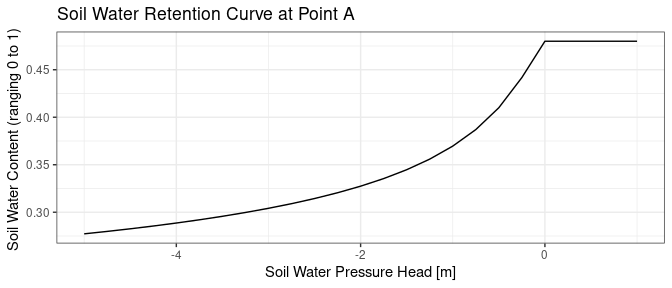

```r
library(ggplot2)
psi <- seq(from=-5,to=1,by=0.25)
title <- "Soil Water Retention Curve at Point A"
xlab <- "Soil Water Pressure Head [m]"
ylab <- "Soil Water Content (ranging 0 to 1) "
gswA <- ggplot()+geom_line(aes(x=psi,y=swcA(psi)))+theme_bw()
gswA <- gswA+ggtitle(title)+xlab(xlab)+ylab(ylab)
gswA
```

Next steps, it is a generalization for the estimation for Soil Water Retention Curve in all cells of the raster map. This means to save the soil water retention curves as an R object for all the cells, and is possible though *rasterList* function:

```r
swc_rl <- rasterList(soil_parameters,FUN=swc_func)
```

The *rasterList-class* object contains each soil water retention curve per each cell. Since the list element refered to each raster cell are *function* class, *swc_rl* is coerced to a single function defined all raster extension though *rasterListFun* *swc_rl* :

```r
swc_rlf <- rasterListFun(swc_rl)
```

In such a way, the function *swc_rlf* can be used to estimate to estimate soil water function given a spatially unimorm value of soi water pressure head $\psi$ on all the region of interest.

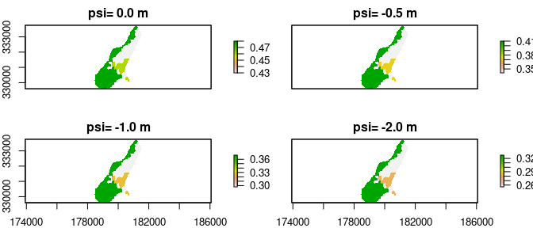

```r
psi <- c(0,-0.5,-1,-2)
names(psi) <- sprintf("psi= %1.1f m",psi)
soil_water_content <- stack(swc_rlf(psi))
names(soil_water_content) <- names(psi)
plot(soil_water_content,main=names(psi))
```

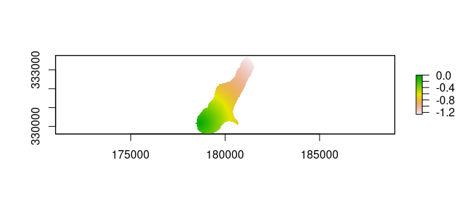

```r
region <- raster(swc_rlf(0))
mask <- !is.na(region)
region[] <- NA
region[points$icell[1]] <- 1
dist <- distance(region)
dist[mask==0] <- NA

mdist <- max(dist[],na.rm=TRUE)

psi_max <- 0
psi_min <- -2
psi <- psi_max+(psi_min-psi_max)*(1-exp(-dist/mdist))
plot(psi)
```

```r
color <- colorNumeric("Blues",domain=psi[])

leaf_psi <- leaf1 %>% addRasterImage(psi,color=color,opacity=opacity) %>%
addLegend(position="bottomright",pal=color,values=psi[],opacity=opacity,title="Psi") %>% addMarkers(lng=points$lon,lat=points$lat,label=points$name)

leaf_psi
```

[interactive chart not shown]

The corresponding map of $\theta$ is the following:

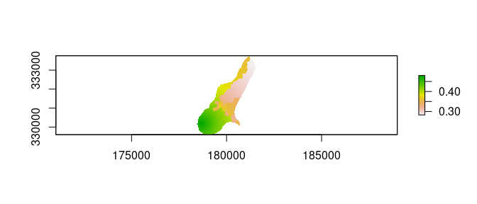

```r
theta <- raster(swc_rlf(psi))
plot(theta)
```

```r
color <- colorNumeric("Blues",domain=theta[])

leaf_psi <- leaf1 %>% addRasterImage(theta,color=color,opacity=opacity) %>%
addLegend(position="bottomright",pal=color,values=theta[],opacity=opacity,title="Psi") %>% addMarkers(lng=points$lon,lat=points$lat,label=points$name)

leaf_psi
```

[interactive chart not shown]

## Application 2

```r
library(rasterList)
##precf <- system.file("map/Mekrou_precipitation.grd", package="rasterList")
precf <- system.file("map/cajamarca_monthly_precipitation.grd", package="rasterList")
precf <- system.file("map/cajamarca_monthly_precipitation_vL.grd", package="rasterList")
prec <- stack(precf)
prec
```

```
#> class      : RasterStack
#> dimensions : 63, 34, 2142, 457  (nrow, ncol, ncell, nlayers)
#> resolution : 0.05, 0.05  (x, y)
#> extent     : -79.45, -77.75, -7.75, -4.6  (xmin, xmax, ymin, ymax)
#> crs        : +proj=longlat +datum=WGS84 +no_defs
#> names      :  X1981.01.01,  X1981.02.01,  X1981.03.01,  X1981.04.01,  X1981.05.01,  X1981.06.01,  X1981.07.01,  X1981.08.01,  X1981.09.01,  X1981.10.01,  X1981.11.01,  X1981.12.01,  X1982.01.01,  X1982.02.01,  X1982.03.01, ...
#> min values : 0.000000e+00, 0.000000e+00, 2.738259e-09, 3.508614e-02, 1.070757e-08, 6.597087e-10, 9.194581e-09, 6.392712e-01, 3.848356e-01, 1.679576e-01, 4.995803e-10, 0.000000e+00, 0.000000e+00, 0.000000e+00, 4.746902e-09, ...
#> max values :    285.14169,    366.55566,    450.19556,    327.21133,    236.27979,    306.26398,    222.97964,    376.98740,    191.33948,    316.09308,    232.63409,    499.08591,    352.42032,    282.62384,    583.06091, ...
```

Total annual precipitation can be computed through an aggregation of monthly data with a *sum* function aggragtion and *lubridate* package (Grolemund and Wickham (2011)).

```r
  ###  independent and identically distributed (i.i.d.
  library(lubridate)

  dates <- as.Date(names(prec),format="X%Y.%m.%d")
  names(dates) <- names(prec)

  years <- year(dates)
  months <- month(dates)

  im <- which(months<8)
  years[im] <- years[im]-1
```

The meteorological year used for aggregation start on 1st August, due to the fact that the region of interest is located in Southern Hemishere. Because precipitation dataset is not aligned with this definitions of the year, it is checked that all meteorological years shall contain 12 months:

```r
lseason <- tapply(X=dates,FUN=length,INDEX=years)
years_c <- names(lseason)[which(lseason==12)]
ic <- which(years %in% years_c)
prec <- prec[[ic]]
years <- years[ic]
months <- months[ic]
```

Then, it is:

```r
  ###
  prec_sum <- stackApply(prec,fun=sum,indices=years-years[1]+1)
  names(prec_sum) <- years[1]+as.numeric(str_replace_all(names(prec_sum),"index_",""))-1
  prec_sum
```

```
#> class      : RasterBrick
#> dimensions : 63, 34, 2142, 37  (nrow, ncol, ncell, nlayers)
#> resolution : 0.05, 0.05  (x, y)
#> extent     : -79.45, -77.75, -7.75, -4.6  (xmin, xmax, ymin, ymax)
#> crs        : +proj=longlat +datum=WGS84 +no_defs
#> source     : memory
#> names      :    X1981,    X1982,    X1983,    X1984,    X1985,    X1986,    X1987,    X1988,    X1989,    X1990,    X1991,    X1992,    X1993,    X1994,    X1995, ...
#> min values : 21.03516, 28.05417, 24.19769, 19.50776, 19.62258, 23.72827, 21.05662, 20.30390, 18.86364, 19.00034, 20.52686, 24.06778, 21.36050, 19.30094, 20.45294, ...
#> max values : 3600.191, 3478.496, 3983.700, 3354.784, 3236.125, 3120.051, 2403.865, 2932.589, 2823.741, 3012.185, 2392.651, 2940.078, 3245.427, 2792.440, 3047.599, ...
```

A quick view of the total annual precipitation in the region is proposed below.

```r
library(leaflet)

ref_url <- "https://server.arcgisonline.com/ArcGIS/rest/services/World_Topo_Map/MapServer/tile/{z}/{y}/{x}"
ref_attr <- "Tiles &copy; Esri &mdash; Esri, DeLorme, NAVTEQ, TomTom, Intermap, iPC, USGS, FAO, NPS, NRCAN, GeoBase, Kadaster NL, Ordnance Survey, Esri Japan, METI, Esri China (Hong Kong), and the GIS User Community"
leaf <- leaflet() %>% addTiles(urlTemplate=ref_url,attribution=ref_attr)


opacity <- 0.6
r <- mean(prec_sum) ###prec_slm[["l_1"]]
#### Domain
mm <- range(r[])
buffer <- 200
mm <- mm+c(-1,1)*buffer
minzero <- TRUE
if (minzero==TRUE) mm[1] <- 0 ## Precipitation cannot be negative
step <- buffer ###10^(ceiling(log(mm[2])/log(10))-2)
domain=seq(from=mm[1],to=mm[2]+step,by=step)

bins <- (length(domain))/2+1
color <- colorBin("YlGnBu", domain = domain,bin=bins)
values <- domain[domain<=max(r[])]

leaf_l_1 <- leaf %>% addRasterImage(r,opacity=opacity,color=color) %>% addLegend(position="bottomright",pal=color,values=values)
leaf_l_1
```

[interactive chart not shown]

Mann-Kendall trend analysis (Pohlert (2018)) is performed in order to detect if annual precipitation is increasing or decreasing with time. Firstly the attention is focused on two check points in the region of interest going from the Andes higlands to the Amazon Rainforest: Cajamarca city and Imaza (Amozanas) (Angoretos and Iquitos - Loreto, Peru - are also reported in the data frame below but ignored and out of the study map):

```r
pts <- data.frame(lat=c(-7.140278,-5.16,-1.55481,-3.784722),lon=c(-78.488889,-78.288889,-74.609001,-73.308333),name=c("Cajamarca","Imaza","Angoteros","Iquitos"),label=c("CJA","IMZ","ANG","IQT"),stringsAsFactors = FALSE)
pts <- pts[1:2,] ## only Cajamarca and Imaza
pts$icell <- cellFromXY(prec_sum,pts[c("lon","lat")])
head(pts)
```

```
#>         lat       lon      name label icell
#> 1 -7.140278 -78.48889 Cajamarca   CJA  1720
#> 2 -5.160000 -78.28889     Imaza   IMZ   398
```

```r
leaf_l_1 %>% addMarkers(lng=pts$lon,lat=pts$lat,label=sprintf("%10.2f mm at %s",r[pts$icell], pts$label))
```

[interactive chart not shown]

Then, Sen’slope is an estimation of the trend which can be computed through the function *sens.slope* function of **trend** package, the computation is extended to the all map using *rasterList* function:

```r
library(trend)

sens.slope_ <- function(x,...) {
  condNA <- all(is.na(x))
  if (condNA) x[] <- -9999
  o <- sens.slope(x,...)
  if (condNA) o[] <- NA
  return(o)
}
prec_sum_sens_slope <- rasterList(prec_sum,FUN=sens.slope_)
```

Then a trend analysis on total annual precipitation has been done. The *sens_slope* variable returns the Mann-Kandall correlation test and Sen’s slope for all raster cells. Focusing on check points, the test results for them are:

```r
lsl <- as.list(prec_sum_sens_slope@list[pts$icell])
names(lsl) <- pts$label
lsl
```

```
#> $CJA
#>
#>  Sen's slope
#>
#> data:  x
#> z = 0.9286, n = 37, p-value = 0.3531
#> alternative hypothesis: true z is not equal to 0
#> 95 percent confidence interval:
#>  -3.189339  7.749039
#> sample estimates:
#> Sen's slope
#>    2.970606
#>
#>
#> $IMZ
#>
#>  Sen's slope
#>
#> data:  x
#> z = 2.0534, n = 37, p-value = 0.04004
#> alternative hypothesis: true z is not equal to 0
#> 95 percent confidence interval:
#>   0.2930253 19.3256042
#> sample estimates:
#> Sen's slope
#>    10.29608
```

```r
  library(gridExtra)
  library(ggplot2)
  getTrend <- function(x,signif=0.05) {

          pval <- x$p.value
          o <- x$estimates
          o[pval>signif] <- 0
          return(o)
  }

  plotTrend <- function(x=prec_sum[pts$icell][1,],trend=NULL,time=1:length(x),signif=0.05,variable.name="VARNAME",title="Title",...) {
    if (is.null(trend)) trend <- sens.slope_(x,...)
    trend <- getTrend(x=trend,signif=signif)
    print(trend)
    xm <- mean(x)
    ylab <- sprintf("%s an. [mm] from mean",variable.name)
    mean <- sprintf("(mean: %5.2f mm)",xm)
    o <- ggplot()+geom_col(aes(x=time,y=x-xm))+theme_bw()
    o <- o+xlab("Time [years]")+ylab(ylab)
    o <- o+ggtitle(paste0(title,"  ",mean))
    intercept <- -trend*time[1]
    o <- o+geom_abline(mapping=NULL,intercept=intercept,slope=trend)
    o <- o+theme(title =element_text(size=8))
    return(o)


  }

  time <- as.numeric(str_replace(names(prec_sum),"X",""))


  prec_sum_sens_slope_trend <- raster(prec_sum_sens_slope,FUN=getTrend)

  ptstrend <- list()
  for (i in 1:nrow(pts)){
    ptstrend[[i]] <- plotTrend(prec_sum[pts$icell][i,],variable.name="MAP",title=sprintf("%s (%s)",pts$name[i],pts$label[i]),time=time)
  }
```

```
#> Sen's slope
#>           0
#> Sen's slope
#>    10.29608
```

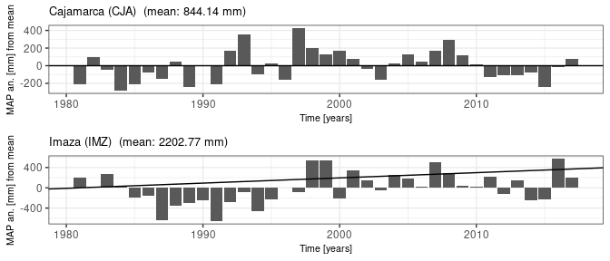

```r
  do.call(what=grid.arrange,args=ptstrend)
```

```r
r <-  prec_sum_sens_slope_trend
#### Domain
mm <- range(r[],na.rm=TRUE)
buffer <- 1  #0.01
mm <- mm+c(-1,1)*buffer
minzero <- TRUE
if (minzero==TRUE) mm[1] <- 0 ## Precipitation cannot be negative
step <- buffer ###10^(ceiling(log(mm[2])/log(10))-2)
domain=seq(from=mm[1],to=mm[2]+step,by=step)

bins <- (length(domain))/2+1
color <- colorBin("YlGnBu", domain =domain,bin=bins)
values <- domain[domain<=max(r[])]

leaf_trend <- leaf %>% addRasterImage(r,opacity=opacity,color=color) %>% addLegend(position="bottomright",pal=color,values=values)

leaf_trend %>% addMarkers(lng=pts$lon,lat=pts$lat,label=sprintf("%10.2f mm/year at %s",r[pts$icell], pts$label))
```

[interactive chart not shown]

Analyzing from data, precipitation trend is greater than 0 in the inner part of the Amazon Rainforest. For further datails, assuming that rainfall is more useful during the vegetative season which corresponds to the most rainy months of year, the analysis is replied using the mean monthly precipitation of the 3 most rainy months per each year. The aggregation is done by inserting this new aggregation function as *FUN* argument of the *rasterList* function:

```r
prec_rank <- rasterList(prec,FUN=function(x,years,xnum){

  o <- tapply(x,INDEX=years,FUN=function(x,n){x[order(x,decreasing=TRUE)][1:n]},n=xnum,simplify=TRUE)
  return(o)

},years=years,xnum=3)

prec_rank_mean <- stack(prec_rank,FUN=function(x,...){

  o <- sapply(X=x,FUN=mean,...)
  return(o)
},na.rm=FALSE)
```

Subsequently, trend analyis is conducted as follows:

```r
prec_rank_mean_sens_slope <- rasterList(prec_rank_mean,FUN=sens.slope_)
prec_rank_mean_sens_slope_trend <- raster(prec_rank_mean_sens_slope,FUN=getTrend)
ptstrend <- list()

 for (i in 1:nrow(pts)){
    ptstrend[[i]] <- plotTrend(prec_rank_mean[pts$icell][i,],variable.name="M3MP",title=sprintf("%s (%s)",pts$name[i],pts$label[i]),time=time)

  }
```

```
#> Sen's slope
#>           0
#> Sen's slope
#>           0
```

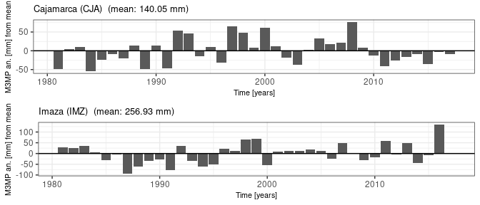

```r
  do.call(what=grid.arrange,args=ptstrend)
```

```r
r <-  prec_rank_mean_sens_slope_trend
#### Domain
mm <- range(r[],na.rm=TRUE)
buffer <- 1  #0.01
mm <- mm+c(-1,1)*buffer
minzero <- TRUE
if (minzero==TRUE) mm[1] <- 0 ## Precipitation cannot be negative
step <- buffer ###10^(ceiling(log(mm[2])/log(10))-2)
domain=seq(from=mm[1],to=mm[2]+step,by=step)

bins <- (length(domain))/2+1
color <- colorBin("YlGnBu", domain =domain,bin=bins)
values <- domain[domain<=max(r[])]

leaf_trend <- leaf %>% addRasterImage(r,opacity=opacity,color=color) %>% addLegend(position="bottomright",pal=color,values=values)

leaf_trend %>% addMarkers(lng=pts$lon,lat=pts$lat,label=sprintf("%10.2f mm/year at %s",r[pts$icell], pts$label))
```

[interactive chart not shown]

The behaviour of mean monthly precipitation within the rainy season is similar to the behaviour of the total annual precipitation. Trends, where significantly exist, are not very high. However, mean monthly precipitation within the rainy season an indicator of rain water availablity for agriculture during the growing season. In the following, both annual mean precipitation and mean monthly precipitation within the rainy season are rescaled and carried out homogenized with the reference to the conditional expected value of the last year of the time series, i.e. 2017, in order that the time series values are assumed to be independent and identically distributed:

```r
  years <- as.numeric(str_replace(names(prec_sum),"X",""))
  years_max <- years[length(years)]
  prec_sum_res <- prec_sum-stack(lapply(X=(years-years_max),FUN="*",prec_sum_sens_slope_trend))
  prec_rank_mean_res <- prec_rank_mean-stack(lapply(X=(years-years_max),FUN="*",prec_rank_mean_sens_slope_trend))
```

```r
  library(lmomPi)
  prec_m_ts <- prec_rank_mean_res[pts$icell[1]]
  lmoments <- samlmu(prec_m_ts,ratios=TRUE)
  para <- pel_lmom(lmoments,distrib=c("pe3","gev"))
  para
```

```
#> $pe3
#>          mu       sigma       gamma
#> 140.0545979  35.2048420   0.6094782
#> attr(,"probability_distrib")
#> [1] "pe3"
#>
#> $gev
#>         xi      alpha          k
#> 125.239011  31.106715   0.112369
#> attr(,"probability_distrib")
#> [1] "gev"
```

```r
  ks <- list()
  for (it in names(para)) {
    ks[[it]] <- ks.test(x=prec_m_ts,y="cdf",para=para[[it]])
  }
  ks
```

```
#> $pe3
#>
#>  One-sample Kolmogorov-Smirnov test
#>
#> data:  prec_m_ts
#> D = 0.067533, p-value = 0.9917
#> alternative hypothesis: two-sided
#>
#>
#> $gev
#>
#>  One-sample Kolmogorov-Smirnov test
#>
#> data:  prec_m_ts
#> D = 0.066567, p-value = 0.993
#> alternative hypothesis: two-sided
```

The procedure is therefore replied at a raster scale (for each pixel of the raster) by defining and creating the following structures: == *samlmom* a *RasterStack-class* Object containing L-Momnts for each pixel; == *fitdist* a *RasterList-class* object describing the probability distribution for each pixel with its parameters; == *kstesting*, a *RasterList-class* containing the output of the Kolgomorov-Smirnov Goodness-of-fit test for each pixel. These objects are repliceted for everery hypothetical probability distrubition.

```r
samlmom <- stack(rasterList(prec_rank_mean_res,FUN=samlmu,ratios=TRUE))
## This is a correction
inas <- is.na(samlmom)
samlmom[inas] <- 0
prec_rank_mean_res[inas] <- -9999
distrib <- c("pe3","gev")
fitdist <- list()
kstesting <- list()
for (it in distrib) {
  fitdist[[it]] <- rasterList(samlmom,FUN=pel_lmom,distrib=it)
  kstesting[[it]] <- RasterListApply(x=rasterList(prec_rank_mean_res),y="cdf",para=fitdist[[it]],FUN=ks.test)
}
kstesting[["pe3"]]@list[[pts$icell[1]]]
```

```
#>
#>  One-sample Kolmogorov-Smirnov test
#>
#> data:  dots[[1L]][[1720L]]
#> D = 0.067533, p-value = 0.9917
#> alternative hypothesis: two-sided
```

THe mapping of *p.value* is useful to assess where the null hypothesis (e.g. the probability distrubution) can be accepted or not. Both selected probability distributions can be accepted for all raster cells.

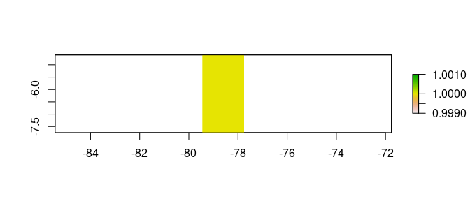

```r
  pval_ks <- list()
  pval_ks[["pe3"]] <- raster(kstesting[["pe3"]],FUN=function(x){x$p.value})
  plot(pval_ks[["pe3"]]>0.1)
```

```r
  pval_ks[["pe3"]]
```

```
#> class      : RasterLayer
#> dimensions : 63, 34, 2142  (nrow, ncol, ncell)
#> resolution : 0.05, 0.05  (x, y)
#> extent     : -79.45, -77.75, -7.75, -4.6  (xmin, xmax, ymin, ymax)
#> crs        : +proj=longlat +datum=WGS84 +no_defs
#> source     : memory
#> names      : X1981
#> values     : 0.149453, 0.9999999  (min, max)
```

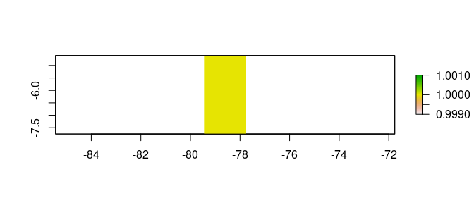

```r
  pval_ks[["gev"]] <- raster(kstesting[["gev"]],FUN=function(x){x$p.value})
  plot(pval_ks[["gev"]]>0.1)
```

```r
  pval_ks[["gev"]]
```

```
#> class      : RasterLayer
#> dimensions : 63, 34, 2142  (nrow, ncol, ncell)
#> resolution : 0.05, 0.05  (x, y)
#> extent     : -79.45, -77.75, -7.75, -4.6  (xmin, xmax, ymin, ymax)
#> crs        : +proj=longlat +datum=WGS84 +no_defs
#> source     : memory
#> names      : X1981
#> values     : 0.2314152, 0.9999998  (min, max)
```

Return period is the expected time interval between two events where precipitation is lower than a certain threshold value. Return periods are a measure of the frequency at which specific events occurs. Since the object is to analyze the meteorological drought (i.e. lack of rainfall), return periods are the inverse of quantiles associeted to a precipitation lower that the mapped value. Under the hypothesis that the probability distribution is Pearson III type (i.e. *pe3*), return periods are calculated as follows:

```r
return_periods <- c(5,10,20,50,100)
frq= 1/return_periods
names(frq) <- sprintf("T%d",return_periods)
percentiles <-  stack(fitdist[["pe3"]],FUN=function(p,frq) {
   o <- qua(f=frq,para=p)
   names(o) <- names(frq)

   return(o)
   },frq=frq)
```

Finally, here is a visualization of the value of mean monthly precitation in the 3 most rainy months of the year that is not reached with a return period of 20 years:

```r
r <-  percentiles[["T20"]]
rp <- r
r[r>1000] <- 1000
#### Domain
mm <- range(r[],na.rm=TRUE)
buffer <- 20  #0.01
mm <- mm+c(-1,1)*buffer
minzero <- TRUE
if (minzero==TRUE) mm[1] <- 0 ## Precipitation cannot be negative
step <- buffer ###10^(ceiling(log(mm[2])/log(10))-2)
domain=seq(from=mm[1],to=mm[2]+step,by=step)

bins <- (length(domain))/2+1
color <- colorBin("YlGnBu", domain =domain,bin=bins)
values <- domain[domain<=max(r[])]

leaf_trp <- leaf %>% addRasterImage(r,opacity=opacity,color=color) %>% addLegend(position="bottomright",pal=color,values=values)

leaf_trp %>% addMarkers(lng=pts$lon,lat=pts$lat,label=sprintf("%10.2f mm at %s",rp[pts$icell], pts$label))
```

[interactive chart not shown]

The user can rerun the code to map other percentiles related to other return periods.

## Conclusions

The above applications illustrate how statistical analysis and other processing may be replicated at every cell of a raster map. The **rasterList** package has been created to answer the need to make complex operation on spatially gridded region. The shown examples go beyond their own task but they have the task of teaching the most important functions of the package and therefore how to make use of the package. **rasterList** is able to save different type of objects within a cell of the raster map and allows that each object of a raster cell may be transformed and/or coerced to another object. Two or more *RasterList-class* objects can interact through operations with one another. This is of great relavance because it allows to save intermediate steps during a processing workflow (e.g. statistical analysis).

## References

n.d. https://www.rdocumentation.org/packages/sp/versions/1.3-1/topics/meuse.

Chambers, J. M. 1992. “Linear Models.” In *Statistical Models in s*. Wadsworth & Brooks/Cole.

Cheng, Joe, Bhaskar Karambelkar, and Yihui Xie. 2018. *Leaflet: Create Interactive Web Maps with the JavaScript ’Leaflet’ Library*. https://CRAN.R-project.org/package=leaflet.

Cordano, Emanuele. 2022. *lmomPi: (Precipitation) Frequency Analysis and Variability with l-Moments from ’Lmom’*. https://CRAN.R-project.org/package=lmomPi.

Cordano, Emanuele, Daniele Andreis, and Fabio Zottele. 2017. *Soilwater: Implementation of Parametric Formulas for Soil Water Retention or Conductivity Curve*. https://CRAN.R-project.org/package=soilwater.

Cordano, Emanuele, and Others. 2018. *rasterList: A Raster Where Cells Are Generic Objects*.

Funk, Chris, Pete Peterson, Martin Landsfeld, Diego Pedreros, James Verdin, Shraddhanand Shukla, Gregory Husak, et al. 2015. “The Climate Hazards Infrared Precipitation with Stations–a New Environmental Record for Monitoring Extremes.” *Scientific Data* 2 (December): 150066 EP–. http://dx.doi.org/10.1038/sdata.2015.66.

Grolemund, Garrett, and Hadley Wickham. 2011. “Dates and Times Made Easy with lubridate.” *Journal of Statistical Software* 40 (3): 1–25. http://www.jstatsoft.org/v40/i03/.

Hastie, T. J., and D. Pregibon. 1992. “Generalized Linear Models.” In *Statistical Models in s*. Wadsworth & Brooks/Cole.

Hijmans, Robert J. 2016. *Raster: Geographic Data Analysis and Modeling*. https://CRAN.R-project.org/package=raster.

Hosking, J. R. M. 2017. *L-Moments*. https://CRAN.R-project.org/package=lmom.

Hosking, J. R. M., and James R. Wallis. 1997. “L-Moments.” In *Regional Frequency Analysis: An Approach Based on l-Moments*, 14–43. Cambridge University Press. https://doi.org/10.1017/CBO9780511529443.004.

Kollet, Stefan, Mauro Sulis, Reed M. Maxwell, Claudio Paniconi, Mario Putti, Giacomo Bertoldi, Ethan T. Coon, et al. 2017. “The Integrated Hydrologic Model Intercomparison Project, IH-Mip2: A Second Set of Benchmark Results to Diagnose Integrated Hydrology and Feedbacks.” *Water Resources Research* 53 (1): 867–90. https://doi.org/10.1002/2016WR019191.

Marsaglia, George, Wai Wan Tsang, and Jingbo Wang. 2003. “Evaluating Kolmogorov’s Distribution.” *Journal of Statistical Software, Articles* 8 (18): 1–4. https://doi.org/10.18637/jss.v008.i18.

Pohlert, Thorsten. 2018. *Trend: Non-Parametric Trend Tests and Change-Point Detection*. https://CRAN.R-project.org/package=trend.

VanGenuchten, M. Th. 1980. “A Closed-Form Equation for Predicting the Hydraulic Conductivity of Unsaturated Soils.” *Soil Sci. Soc. Am. Jour.* 44: 892–98.